# Assignment 4

Before working on this assignment please read these instructions fully. In the submission area, you will notice that you can click the link to **Preview the Grading** for each step of the assignment. This is the criteria that will be used for peer grading. Please familiarize yourself with the criteria before beginning the assignment.

This assignment requires that you to find **at least** two datasets on the web which are related, and that you visualize these datasets to answer a question with the broad topic of **weather phenomena** (see below) for the region of **Ann Arbor, Michigan, United States**, or **United States** more broadly.

You can merge these datasets with data from different regions if you like! For instance, you might want to compare **Ann Arbor, Michigan, United States** to Ann Arbor, USA. In that case at least one source file must be about **Ann Arbor, Michigan, United States**.

You are welcome to choose datasets at your discretion, but keep in mind **they will be shared with your peers**, so choose appropriate datasets. Sensitive, confidential, illicit, and proprietary materials are not good choices for datasets for this assignment. You are welcome to upload datasets of your own as well, and link to them using a third party repository such as github, bitbucket, pastebin, etc. Please be aware of the Coursera terms of service with respect to intellectual property.

Also, you are welcome to preserve data in its original language, but for the purposes of grading you should provide english translations. You are welcome to provide multiple visuals in different languages if you would like!

As this assignment is for the whole course, you must incorporate principles discussed in the first week, such as having as high data-ink ratio (Tufte) and aligning with Cairo’s principles of truth, beauty, function, and insight.

Here are the assignment instructions:

- State the region and the domain category that your data sets are about (e.g., **Ann Arbor, Michigan, United States** and **weather phenomena**).
- You must state a question about the domain category and region that you identified as being interesting.
- You must provide at least two links to available datasets. These could be links to files such as CSV or Excel files, or links to websites which might have data in tabular form, such as Wikipedia pages.
- You must upload an image which addresses the research question you stated. In addition to addressing the question, this visual should follow Cairo's principles of truthfulness, functionality, beauty, and insightfulness.
- You must contribute a short (1-2 paragraph) written justification of how your visualization addresses your stated research question.

What do we mean by **weather phenomena**? For this category you might want to consider seasonal changes, natural disasters, or historical trends.

## Tips

- Wikipedia is an excellent source of data, and I strongly encourage you to explore it for new data sources.
- Many governments run open data initiatives at the city, region, and country levels, and these are wonderful resources for localized data sources.
- Several international agencies, such as the [United Nations](http://data.un.org/), the [World Bank](http://data.worldbank.org/), the [Global Open Data Index](http://index.okfn.org/place/) are other great places to look for data.
- This assignment requires you to convert and clean datafiles. Check out the discussion forums for tips on how to do this from various sources, and share your successes with your fellow students!

## Example

Looking for an example? Here's what our course assistant put together for the **Ann Arbor, MI, USA** area using **sports and athletics** as the topic. Example Solution File

```python
import pandas as pd
f = ['SP1 01-02.csv', 'SP1 02-03.csv', 'SP1 03-04.csv', 'SP1 04-05.csv', 'SP1 05-06.csv', 'SP1 06-07.csv', 'SP1 07-08.csv', 'SP1 08-09.csv', 'SP1 09-10.csv', 'SP1 10-11.csv', 'SP1 11-12.csv', 'SP1 12-13.csv', 'SP1 13-14.csv', 'SP1 14-15.csv', 'SP1 15-16.csv', 'SP1 16-17.csv', 'SP1 97-98.csv', 'SP1 98-99.csv', 'SP1 99-00.csv', 'SP1 00-01.csv']
f
```

```
['SP1 01-02.csv',
 'SP1 02-03.csv',
 'SP1 03-04.csv',
 'SP1 04-05.csv',
 'SP1 05-06.csv',
 'SP1 06-07.csv',
 'SP1 07-08.csv',
 'SP1 08-09.csv',
 'SP1 09-10.csv',
 'SP1 10-11.csv',
 'SP1 11-12.csv',
 'SP1 12-13.csv',
 'SP1 13-14.csv',
 'SP1 14-15.csv',
 'SP1 15-16.csv',
 'SP1 16-17.csv',
 'SP1 97-98.csv',
 'SP1 98-99.csv',
 'SP1 99-00.csv',
 'SP1 00-01.csv']
```

```python
data = pd.read_csv('SP1 01-02.csv')
data['season'] = str('SP1 01-02.csv')[4:9]
data
```

|  | Div | Date | HomeTeam | AwayTeam | FTHG | FTAG | FTR | HTHG | HTAG | HTR | ... | SBH | SBD | SBA | SYH | SYD | SYA | WHH | WHD | WHA | season |
| --- | --- | --- | --- | --- | --- | --- | --- | --- | --- | --- | --- | --- | --- | --- | --- | --- | --- | --- | --- | --- | --- |
| 0 | SP1 | 25/08/01 | Valencia | Real Madrid | 1 | 0 | H | 1 | 0 | H | ... | NaN | NaN | NaN | 2.600 | 3.000 | 2.500 | 2.75 | 3.10 | 2.30 | 01-02 |
| 1 | SP1 | 26/08/01 | La Coruna | Valladolid | 4 | 0 | H | 1 | 0 | H | ... | NaN | NaN | NaN | 1.330 | 4.330 | 7.000 | 1.30 | 4.20 | 8.50 | 01-02 |
| 2 | SP1 | 26/08/01 | Espanol | Zaragoza | 2 | 1 | H | 1 | 1 | D | ... | NaN | NaN | NaN | 1.910 | 3.200 | 3.500 | 1.83 | 3.40 | 3.50 | 01-02 |
| 3 | SP1 | 26/08/01 | Malaga | Betis | 3 | 2 | H | 1 | 1 | D | ... | NaN | NaN | NaN | 1.830 | 3.200 | 3.750 | 1.80 | 3.40 | 3.60 | 01-02 |
| 4 | SP1 | 26/08/01 | Mallorca | Las Palmas | 0 | 3 | A | 0 | 1 | A | ... | NaN | NaN | NaN | 1.440 | 3.600 | 6.500 | 1.44 | 3.50 | 7.00 | 01-02 |
| 5 | SP1 | 26/08/01 | Osasuna | Celta | 0 | 3 | A | 0 | 1 | A | ... | NaN | NaN | NaN | 2.600 | 3.200 | 2.380 | NaN | NaN | NaN | 01-02 |
| 6 | SP1 | 26/08/01 | Sociedad | Ath Bilbao | 1 | 3 | A | 1 | 1 | D | ... | NaN | NaN | NaN | 2.200 | 3.000 | 3.000 | 2.20 | 3.20 | 2.80 | 01-02 |
| 7 | SP1 | 26/08/01 | Vallecano | Villarreal | 1 | 2 | A | 1 | 2 | A | ... | NaN | NaN | NaN | 2.200 | 3.200 | 2.800 | 2.25 | 3.20 | 2.75 | 01-02 |
| 8 | SP1 | 26/08/01 | Sevilla | Barcelona | 1 | 2 | A | 0 | 1 | A | ... | NaN | NaN | NaN | 3.750 | 3.250 | 1.800 | 3.75 | 3.20 | 1.83 | 01-02 |
| 9 | SP1 | 26/08/01 | Tenerife | Alaves | 0 | 2 | A | 0 | 1 | A | ... | NaN | NaN | NaN | 2.380 | 3.200 | 2.600 | 2.25 | 3.20 | 2.75 | 01-02 |
| 10 | SP1 | 08/09/01 | Ath Bilbao | Mallorca | 0 | 1 | A | 0 | 0 | D | ... | 2.100 | 3.100 | 3.100 | 2.100 | 3.200 | 3.000 | 2.00 | 3.20 | 3.20 | 01-02 |
| 11 | SP1 | 08/09/01 | Las Palmas | La Coruna | 0 | 1 | A | 0 | 0 | D | ... | 2.900 | 3.000 | 2.250 | 2.880 | 3.000 | 2.250 | 2.80 | 3.00 | 2.30 | 01-02 |
| 12 | SP1 | 08/09/01 | Real Madrid | Malaga | 1 | 1 | D | 1 | 0 | H | ... | 1.300 | 4.330 | 8.000 | 1.330 | 4.330 | 7.000 | 1.25 | 4.50 | 10.00 | 01-02 |
| 13 | SP1 | 08/09/01 | Villarreal | Osasuna | 3 | 0 | H | 1 | 0 | H | ... | 1.500 | 3.400 | 6.000 | 1.500 | 3.400 | 6.000 | NaN | NaN | NaN | 01-02 |
| 14 | SP1 | 09/09/01 | Alaves | Sociedad | 2 | 0 | H | 1 | 0 | H | ... | 1.700 | 3.250 | 4.330 | 1.800 | 3.000 | 4.330 | 1.80 | 3.30 | 3.75 | 01-02 |
| 15 | SP1 | 09/09/01 | Barcelona | Vallecano | 1 | 1 | D | 0 | 0 | D | ... | 1.300 | 4.330 | 8.000 | 1.290 | 4.500 | 8.000 | 1.28 | 4.50 | 8.00 | 01-02 |
| 16 | SP1 | 09/09/01 | Betis | Espanol | 2 | 0 | H | 2 | 0 | H | ... | 2.200 | 3.000 | 3.000 | 2.380 | 3.200 | 2.620 | 2.20 | 3.00 | 3.00 | 01-02 |
| 17 | SP1 | 09/09/01 | Celta | Tenerife | 3 | 0 | H | 2 | 0 | H | ... | 1.360 | 3.800 | 7.500 | 1.400 | 3.750 | 7.000 | 1.36 | 3.75 | 8.00 | 01-02 |
| 18 | SP1 | 09/09/01 | Valladolid | Valencia | 1 | 1 | D | 1 | 0 | H | ... | 3.000 | 3.000 | 2.200 | 2.800 | 3.200 | 2.200 | 2.80 | 3.10 | 2.25 | 01-02 |
| 19 | SP1 | 09/09/01 | Zaragoza | Sevilla | 1 | 1 | D | 0 | 0 | D | ... | 1.700 | 3.250 | 4.330 | 1.670 | 3.250 | 4.500 | 1.61 | 3.30 | 5.00 | 01-02 |
| 20 | SP1 | 15/09/01 | Betis | Real Madrid | 3 | 1 | H | 1 | 1 | D | ... | 3.500 | 3.200 | 1.910 | 3.750 | 3.200 | 1.830 | 3.40 | 3.25 | 1.90 | 01-02 |
| 21 | SP1 | 15/09/01 | La Coruna | Ath Bilbao | 1 | 2 | A | 0 | 1 | A | ... | 1.360 | 3.750 | 8.000 | 1.400 | 3.750 | 7.000 | 1.36 | 3.75 | 8.00 | 01-02 |
| 22 | SP1 | 15/09/01 | Mallorca | Alaves | 0 | 0 | D | 0 | 0 | D | ... | 1.730 | 3.200 | 4.330 | 1.670 | 3.250 | 4.500 | 1.72 | 3.20 | 4.33 | 01-02 |
| 23 | SP1 | 15/09/01 | Osasuna | Barcelona | 0 | 0 | D | 0 | 0 | D | ... | 4.000 | 3.400 | 1.730 | 3.750 | 3.250 | 1.800 | NaN | NaN | NaN | 01-02 |
| 24 | SP1 | 16/09/01 | Espanol | Sevilla | 2 | 3 | A | 1 | 1 | D | ... | 1.670 | 3.250 | 4.600 | 1.670 | 3.250 | 4.500 | 1.61 | 3.30 | 5.00 | 01-02 |
| 25 | SP1 | 16/09/01 | Malaga | Valladolid | 1 | 2 | A | 0 | 1 | A | ... | 1.620 | 3.300 | 5.000 | 1.670 | 3.250 | 4.500 | 1.61 | 3.30 | 5.00 | 01-02 |
| 26 | SP1 | 16/09/01 | Sociedad | Celta | 0 | 0 | D | 0 | 0 | D | ... | 3.000 | 3.200 | 2.100 | 2.800 | 3.200 | 2.200 | 2.70 | 3.10 | 2.30 | 01-02 |
| 27 | SP1 | 16/09/01 | Vallecano | Zaragoza | 1 | 2 | A | 1 | 0 | H | ... | 2.000 | 3.100 | 3.300 | 2.100 | 3.000 | 3.200 | 1.90 | 3.20 | 3.50 | 01-02 |
| 28 | SP1 | 16/09/01 | Tenerife | Villarreal | 2 | 0 | H | 1 | 0 | H | ... | 2.620 | 3.100 | 2.380 | 2.380 | 3.100 | 2.620 | 2.50 | 3.10 | 2.50 | 01-02 |
| 29 | SP1 | 16/09/01 | Valencia | Las Palmas | 1 | 0 | H | 0 | 0 | D | ... | 1.330 | 4.000 | 8.000 | 1.360 | 4.000 | 7.000 | 1.50 | 2.87 | 9.00 | 01-02 |
| ... | ... | ... | ... | ... | ... | ... | ... | ... | ... | ... | ... | ... | ... | ... | ... | ... | ... | ... | ... | ... | ... |
| 350 | SP1 | 27/04/02 | Barcelona | Villarreal | 4 | 1 | H | 0 | 1 | A | ... | NaN | NaN | NaN | 1.300 | 4.333 | 8.000 | NaN | NaN | NaN | 01-02 |
| 351 | SP1 | 27/04/02 | Sociedad | Real Madrid | 3 | 0 | H | 0 | 0 | D | ... | NaN | NaN | NaN | 4.500 | 3.500 | 1.615 | NaN | NaN | NaN | 01-02 |
| 352 | SP1 | 27/04/02 | Valencia | Espanol | 2 | 1 | H | 0 | 1 | A | ... | NaN | NaN | NaN | 1.286 | 4.500 | 8.000 | NaN | NaN | NaN | 01-02 |
| 353 | SP1 | 28/04/02 | La Coruna | Malaga | 2 | 2 | D | 1 | 1 | D | ... | NaN | NaN | NaN | 1.364 | 4.000 | 7.000 | NaN | NaN | NaN | 01-02 |
| 354 | SP1 | 28/04/02 | Mallorca | Betis | 1 | 3 | A | 0 | 1 | A | ... | NaN | NaN | NaN | 2.000 | 3.200 | 3.200 | NaN | NaN | NaN | 01-02 |
| 355 | SP1 | 28/04/02 | Osasuna | Las Palmas | 3 | 2 | H | 2 | 1 | H | ... | NaN | NaN | NaN | 1.909 | 3.000 | 3.750 | NaN | NaN | NaN | 01-02 |
| 356 | SP1 | 28/04/02 | Vallecano | Ath Bilbao | 4 | 2 | H | 1 | 0 | H | ... | NaN | NaN | NaN | 1.667 | 3.250 | 4.500 | NaN | NaN | NaN | 01-02 |
| 357 | SP1 | 28/04/02 | Sevilla | Alaves | 2 | 0 | H | 1 | 0 | H | ... | NaN | NaN | NaN | 2.200 | 2.875 | 3.100 | NaN | NaN | NaN | 01-02 |
| 358 | SP1 | 28/04/02 | Tenerife | Valladolid | 1 | 5 | A | 0 | 2 | A | ... | NaN | NaN | NaN | 1.833 | 3.200 | 3.750 | NaN | NaN | NaN | 01-02 |
| 359 | SP1 | 28/04/02 | Zaragoza | Celta | 0 | 1 | A | 0 | 0 | D | ... | NaN | NaN | NaN | 2.500 | 3.100 | 2.500 | NaN | NaN | NaN | 01-02 |
| 360 | SP1 | 05/05/02 | Alaves | Vallecano | 0 | 1 | A | 0 | 0 | D | ... | 1.667 | 3.100 | 5.000 | NaN | NaN | NaN | NaN | NaN | NaN | 01-02 |
| 361 | SP1 | 05/05/02 | Ath Bilbao | Osasuna | 1 | 1 | D | 0 | 0 | D | ... | 2.200 | 3.100 | 2.875 | NaN | NaN | NaN | NaN | NaN | NaN | 01-02 |
| 362 | SP1 | 05/05/02 | Barcelona | Espanol | 2 | 0 | H | 1 | 0 | H | ... | 1.286 | 4.500 | 9.000 | 1.333 | 4.000 | 8.000 | NaN | NaN | NaN | 01-02 |
| 363 | SP1 | 05/05/02 | Betis | La Coruna | 0 | 3 | A | 0 | 1 | A | ... | 2.375 | 3.200 | 2.600 | 2.375 | 3.000 | 2.700 | NaN | NaN | NaN | 01-02 |
| 364 | SP1 | 05/05/02 | Celta | Sevilla | 1 | 2 | A | 1 | 2 | A | ... | 1.364 | 4.000 | 7.000 | NaN | NaN | NaN | NaN | NaN | NaN | 01-02 |
| 365 | SP1 | 05/05/02 | Las Palmas | Tenerife | 0 | 1 | A | 0 | 1 | A | ... | 1.727 | 3.400 | 4.000 | 1.727 | 3.400 | 4.000 | NaN | NaN | NaN | 01-02 |
| 366 | SP1 | 05/05/02 | Malaga | Valencia | 0 | 2 | A | 0 | 2 | A | ... | 3.400 | 2.875 | 2.100 | 3.750 | 3.000 | 1.909 | NaN | NaN | NaN | 01-02 |
| 367 | SP1 | 05/05/02 | Real Madrid | Mallorca | 0 | 0 | D | 0 | 0 | D | ... | 1.200 | 5.000 | 11.000 | 1.250 | 4.500 | 10.000 | NaN | NaN | NaN | 01-02 |
| 368 | SP1 | 05/05/02 | Valladolid | Sociedad | 1 | 3 | A | 1 | 1 | D | ... | 1.950 | 3.000 | 3.600 | NaN | NaN | NaN | NaN | NaN | NaN | 01-02 |
| 369 | SP1 | 05/05/02 | Villarreal | Zaragoza | 2 | 1 | H | 2 | 0 | H | ... | 1.571 | 3.300 | 5.500 | 1.800 | 3.250 | 3.750 | NaN | NaN | NaN | 01-02 |
| 370 | SP1 | 10/05/02 | La Coruna | Real Madrid | 3 | 0 | H | 1 | 0 | H | ... | 2.100 | 3.100 | 3.100 | 2.000 | 3.200 | 3.200 | NaN | NaN | NaN | 01-02 |
| 371 | SP1 | 11/05/02 | Espanol | Malaga | 1 | 2 | A | 0 | 2 | A | ... | 2.250 | 3.200 | 2.750 | NaN | NaN | NaN | NaN | NaN | NaN | 01-02 |
| 372 | SP1 | 11/05/02 | Mallorca | Valladolid | 2 | 1 | H | 0 | 1 | A | ... | 1.333 | 4.333 | 7.000 | NaN | NaN | NaN | NaN | NaN | NaN | 01-02 |
| 373 | SP1 | 11/05/02 | Osasuna | Alaves | 0 | 1 | A | 0 | 1 | A | ... | NaN | NaN | NaN | NaN | NaN | NaN | NaN | NaN | NaN | 01-02 |
| 374 | SP1 | 11/05/02 | Sociedad | Las Palmas | 1 | 1 | D | 0 | 1 | A | ... | 2.400 | 3.300 | 2.400 | NaN | NaN | NaN | NaN | NaN | NaN | 01-02 |
| 375 | SP1 | 11/05/02 | Vallecano | Celta | 1 | 0 | H | 0 | 0 | D | ... | 2.625 | 3.200 | 2.300 | 2.700 | 3.200 | 2.250 | NaN | NaN | NaN | 01-02 |
| 376 | SP1 | 11/05/02 | Sevilla | Villarreal | 1 | 0 | H | 1 | 0 | H | ... | NaN | NaN | NaN | 1.400 | 3.750 | 7.000 | NaN | NaN | NaN | 01-02 |
| 377 | SP1 | 11/05/02 | Tenerife | Ath Bilbao | 2 | 3 | A | 2 | 1 | H | ... | 1.727 | 3.500 | 3.800 | 1.800 | 3.500 | 3.500 | NaN | NaN | NaN | 01-02 |
| 378 | SP1 | 11/05/02 | Valencia | Betis | 2 | 0 | H | 1 | 0 | H | ... | 1.571 | 3.400 | 5.000 | 1.571 | 3.500 | 5.000 | NaN | NaN | NaN | 01-02 |
| 379 | SP1 | 11/05/02 | Zaragoza | Barcelona | 1 | 1 | D | 1 | 1 | D | ... | 5.500 | 3.250 | 1.571 | 6.000 | 3.100 | 1.571 | NaN | NaN | NaN | 01-02 |

380 rows × 29 columns

```python
for i in range(1,len(f)):
    print(f[i])
    df = pd.read_csv(f[i], error_bad_lines=False)
    df['season'] = str(f[i])[4:9]
    data = pd.concat([data,df])
```

```
SP1 02-03.csv
SP1 03-04.csv
SP1 04-05.csv
SP1 05-06.csv
SP1 06-07.csv
SP1 07-08.csv
```

[output not shown]

```
SP1 08-09.csv
SP1 09-10.csv
SP1 10-11.csv
SP1 11-12.csv
SP1 12-13.csv
SP1 13-14.csv
SP1 14-15.csv
SP1 15-16.csv
SP1 16-17.csv
SP1 97-98.csv
SP1 98-99.csv
SP1 99-00.csv
SP1 00-01.csv
```

```python
list(data.columns)
```

```
['AC',
 'AF',
 'AR',
 'AS',
 'AST',
 'AY',
 'AwayTeam',
 'B365<2.5',
 'B365>2.5',
 'B365A',
 'B365AH',
 'B365AHA',
 'B365AHH',
 'B365D',
 'B365H',
 'BSA',
 'BSD',
 'BSH',
 'BWA',
 'BWD',
 'BWH',
 'Bb1X2',
 'BbAH',
 'BbAHh',
 'BbAv<2.5',
 'BbAv>2.5',
 'BbAvA',
 'BbAvAHA',
 'BbAvAHH',
 'BbAvD',
 'BbAvH',
 'BbMx<2.5',
 'BbMx>2.5',
 'BbMxA',
 'BbMxAHA',
 'BbMxAHH',
 'BbMxD',
 'BbMxH',
 'BbOU',
 'Date',
```

[output cut: 59 more lines]

```
 'Unnamed: 20',
 'Unnamed: 44',
 'Unnamed: 45',
 'Unnamed: 46',
 'Unnamed: 47',
 'Unnamed: 48',
 'Unnamed: 49',
 'Unnamed: 50',
 'VCA',
 'VCD',
 'VCH',
 'WHA',
 'WHD',
 'WHH',
 'season']
```

```python
cols = ['AwayTeam','HomeTeam','FTR','Date','season']
df = data[cols]
```

```python
df['Month-Date'], df['Year'] = zip(*df['Date'].apply(lambda x: (str(x)[:5], str(x)[6:])))
```

```python
df
```

|  | AwayTeam | HomeTeam | FTR | Date | season | Month-Date | Year |
| --- | --- | --- | --- | --- | --- | --- | --- |
| 0 | Real Madrid | Valencia | H | 25/08/01 | 01-02 | 25/08 | 01 |
| 1 | Valladolid | La Coruna | H | 26/08/01 | 01-02 | 26/08 | 01 |
| 2 | Zaragoza | Espanol | H | 26/08/01 | 01-02 | 26/08 | 01 |
| 3 | Betis | Malaga | H | 26/08/01 | 01-02 | 26/08 | 01 |
| 4 | Las Palmas | Mallorca | A | 26/08/01 | 01-02 | 26/08 | 01 |
| 5 | Celta | Osasuna | A | 26/08/01 | 01-02 | 26/08 | 01 |
| 6 | Ath Bilbao | Sociedad | A | 26/08/01 | 01-02 | 26/08 | 01 |
| 7 | Villarreal | Vallecano | A | 26/08/01 | 01-02 | 26/08 | 01 |
| 8 | Barcelona | Sevilla | A | 26/08/01 | 01-02 | 26/08 | 01 |
| 9 | Alaves | Tenerife | A | 26/08/01 | 01-02 | 26/08 | 01 |
| 10 | Mallorca | Ath Bilbao | A | 08/09/01 | 01-02 | 08/09 | 01 |
| 11 | La Coruna | Las Palmas | A | 08/09/01 | 01-02 | 08/09 | 01 |
| 12 | Malaga | Real Madrid | D | 08/09/01 | 01-02 | 08/09 | 01 |
| 13 | Osasuna | Villarreal | H | 08/09/01 | 01-02 | 08/09 | 01 |
| 14 | Sociedad | Alaves | H | 09/09/01 | 01-02 | 09/09 | 01 |
| 15 | Vallecano | Barcelona | D | 09/09/01 | 01-02 | 09/09 | 01 |
| 16 | Espanol | Betis | H | 09/09/01 | 01-02 | 09/09 | 01 |
| 17 | Tenerife | Celta | H | 09/09/01 | 01-02 | 09/09 | 01 |
| 18 | Valencia | Valladolid | D | 09/09/01 | 01-02 | 09/09 | 01 |
| 19 | Sevilla | Zaragoza | D | 09/09/01 | 01-02 | 09/09 | 01 |
| 20 | Real Madrid | Betis | H | 15/09/01 | 01-02 | 15/09 | 01 |
| 21 | Ath Bilbao | La Coruna | A | 15/09/01 | 01-02 | 15/09 | 01 |
| 22 | Alaves | Mallorca | D | 15/09/01 | 01-02 | 15/09 | 01 |
| 23 | Barcelona | Osasuna | D | 15/09/01 | 01-02 | 15/09 | 01 |
| 24 | Sevilla | Espanol | A | 16/09/01 | 01-02 | 16/09 | 01 |
| 25 | Valladolid | Malaga | A | 16/09/01 | 01-02 | 16/09 | 01 |
| 26 | Celta | Sociedad | D | 16/09/01 | 01-02 | 16/09 | 01 |
| 27 | Zaragoza | Vallecano | A | 16/09/01 | 01-02 | 16/09 | 01 |
| 28 | Villarreal | Tenerife | H | 16/09/01 | 01-02 | 16/09 | 01 |
| 29 | Las Palmas | Valencia | H | 16/09/01 | 01-02 | 16/09 | 01 |
| ... | ... | ... | ... | ... | ... | ... | ... |
| 350 | Celta | Las Palmas | A | 26/05/01 | 00-01 | 26/05 | 01 |
| 351 | Alaves | Real Madrid | H | 26/05/01 | 00-01 | 26/05 | 01 |
| 352 | Malaga | Ath Bilbao | A | 27/05/01 | 00-01 | 27/05 | 01 |
| 353 | Oviedo | Barcelona | A | 27/05/01 | 00-01 | 27/05 | 01 |
| 354 | Valladolid | La Coruna | A | 27/05/01 | 00-01 | 27/05 | 01 |
| 355 | Vallecano | Mallorca | H | 27/05/01 | 00-01 | 27/05 | 01 |
| 356 | Espanol | Numancia | H | 27/05/01 | 00-01 | 27/05 | 01 |
| 357 | Valencia | Santander | D | 27/05/01 | 00-01 | 27/05 | 01 |
| 358 | Osasuna | Villarreal | H | 27/05/01 | 00-01 | 27/05 | 01 |
| 359 | Sociedad | Zaragoza | D | 27/05/01 | 00-01 | 27/05 | 01 |
| 360 | Mallorca | Alaves | A | 10/06/01 | 00-01 | 10/06 | 01 |
| 361 | Sociedad | Ath Bilbao | A | 10/06/01 | 00-01 | 10/06 | 01 |
| 362 | Villarreal | Celta | H | 10/06/01 | 00-01 | 10/06 | 01 |
| 363 | Las Palmas | Espanol | H | 10/06/01 | 00-01 | 10/06 | 01 |
| 364 | Santander | Malaga | H | 10/06/01 | 00-01 | 10/06 | 01 |
| 365 | Zaragoza | Osasuna | H | 10/06/01 | 00-01 | 10/06 | 01 |
| 366 | Real Madrid | Oviedo | D | 10/06/01 | 00-01 | 10/06 | 01 |
| 367 | Numancia | Vallecano | H | 10/06/01 | 00-01 | 10/06 | 01 |
| 368 | La Coruna | Valencia | A | 10/06/01 | 00-01 | 10/06 | 01 |
| 369 | Barcelona | Valladolid | D | 10/06/01 | 00-01 | 10/06 | 01 |
| 370 | Vallecano | Las Palmas | H | 16/06/01 | 00-01 | 16/06 | 01 |
| 371 | Alaves | Numancia | H | 16/06/01 | 00-01 | 16/06 | 01 |
| 372 | Ath Bilbao | Santander | H | 16/06/01 | 00-01 | 16/06 | 01 |
| 373 | Espanol | Villarreal | H | 16/06/01 | 00-01 | 16/06 | 01 |
| 374 | Valencia | Barcelona | H | 17/06/01 | 00-01 | 17/06 | 01 |
| 375 | Malaga | La Coruna | H | 17/06/01 | 00-01 | 17/06 | 01 |
| 376 | Oviedo | Mallorca | H | 17/06/01 | 00-01 | 17/06 | 01 |
| 377 | Valladolid | Real Madrid | H | 17/06/01 | 00-01 | 17/06 | 01 |
| 378 | Osasuna | Sociedad | A | 17/06/01 | 00-01 | 17/06 | 01 |
| 379 | Celta | Zaragoza | D | 17/06/01 | 00-01 | 17/06 | 01 |

7660 rows × 7 columns

```python
rma = df[((df['AwayTeam'] == 'Real Madrid') & (df['FTR'] == 'A')) | ((df['HomeTeam'] == 'Real Madrid') & (df['FTR'] == 'H')) ].sort(columns = ['Year'])
```

```python
fcb = df[((df['AwayTeam'] == 'Barcelona') & (df['FTR'] == 'A')) | ((df['HomeTeam'] == 'Barcelona') & (df['FTR'] == 'H')) ].sort(columns = ['Year'])
```

```python
atm = df[((df['AwayTeam'] == 'Ath Madrid') & (df['FTR'] == 'A')) | ((df['HomeTeam'] == 'Ath Madrid') & (df['FTR'] == 'H')) ].sort(columns = ['Year'])
```

```python
vil = df[((df['AwayTeam'] == 'Villareal') & (df['FTR'] == 'A')) | ((df['HomeTeam'] == 'Villareal') & (df['FTR'] == 'H')) | ((df['AwayTeam'] == 'Villarreal') & (df['FTR'] == 'A')) | ((df['HomeTeam'] == 'Villarreal') & (df['FTR'] == 'H')) ].sort(columns = ['Year'])
```

```python
vil_w = vil[['FTR','season']].groupby(['season']).agg(['count'])
rma_w = rma[['FTR','season']].groupby(['season']).agg(['count'])
fcb_w = fcb[['FTR','season']].groupby(['season']).agg(['count'])
atm_w = atm[['FTR','season']].groupby(['season']).agg(['count'])
```

```python
rma_w.reset_index(inplace= True)
fcb_w.reset_index(inplace= True)
atm_w.reset_index(inplace= True)
vil_w.reset_index(inplace= True)
```

```python
rma_w
```

|  | season | FTR count |
| --- | --- | --- |
| 0 | 00-01 | 24 |
| 1 | 01-02 | 19 |
| 2 | 02-03 | 22 |
| 3 | 03-04 | 21 |
| 4 | 04-05 | 18 |
| 5 | 05-06 | 20 |
| 6 | 06-07 | 23 |
| 7 | 07-08 | 27 |
| 8 | 08-09 | 25 |
| 9 | 09-10 | 31 |
| 10 | 10-11 | 29 |
| 11 | 11-12 | 32 |
| 12 | 12-13 | 26 |
| 13 | 13-14 | 27 |
| 14 | 14-15 | 30 |
| 15 | 15-16 | 28 |
| 16 | 16-17 | 29 |
| 17 | 97-98 | 17 |
| 18 | 98-99 | 21 |
| 19 | 99-00 | 16 |

```python
rma_w['20s'] = rma_w[(rma_w['season'] != '97-98') & (rma_w['season'] != '98-99') & (rma_w['season'] != '99-00')]['season'].apply(lambda x: '20'+x)
rma_w['19s'] = rma_w[(rma_w['season'] == '97-98') | (rma_w['season'] == '98-99') | (rma_w['season'] == '99-00')]['season'].apply(lambda x: '19'+x)
rma_w
```

|  | season | FTR count | 20s | 19s |
| --- | --- | --- | --- | --- |
| 0 | 00-01 | 24 | 2000-01 | NaN |
| 1 | 01-02 | 19 | 2001-02 | NaN |
| 2 | 02-03 | 22 | 2002-03 | NaN |
| 3 | 03-04 | 21 | 2003-04 | NaN |
| 4 | 04-05 | 18 | 2004-05 | NaN |
| 5 | 05-06 | 20 | 2005-06 | NaN |
| 6 | 06-07 | 23 | 2006-07 | NaN |
| 7 | 07-08 | 27 | 2007-08 | NaN |
| 8 | 08-09 | 25 | 2008-09 | NaN |
| 9 | 09-10 | 31 | 2009-10 | NaN |
| 10 | 10-11 | 29 | 2010-11 | NaN |
| 11 | 11-12 | 32 | 2011-12 | NaN |
| 12 | 12-13 | 26 | 2012-13 | NaN |
| 13 | 13-14 | 27 | 2013-14 | NaN |
| 14 | 14-15 | 30 | 2014-15 | NaN |
| 15 | 15-16 | 28 | 2015-16 | NaN |
| 16 | 16-17 | 29 | 2016-17 | NaN |
| 17 | 97-98 | 17 | NaN | 1997-98 |
| 18 | 98-99 | 21 | NaN | 1998-99 |
| 19 | 99-00 | 16 | NaN | 1999-00 |

```python
fcb_w['20s'] = fcb_w[(fcb_w['season'] != '97-98') & (fcb_w['season'] != '98-99') & (fcb_w['season'] != '99-00')]['season'].apply(lambda x: '20'+x)
fcb_w['19s'] = fcb_w[(fcb_w['season'] == '97-98') | (fcb_w['season'] == '98-99') | (fcb_w['season'] == '99-00')]['season'].apply(lambda x: '19'+x)
atm_w['20s'] = atm_w[(atm_w['season'] != '97-98') & (atm_w['season'] != '98-99') & (atm_w['season'] != '99-00')]['season'].apply(lambda x: '20'+x)
atm_w['19s'] = atm_w[(atm_w['season'] == '97-98') | (atm_w['season'] == '98-99') | (atm_w['season'] == '99-00')]['season'].apply(lambda x: '19'+x)
vil_w['20s'] = vil_w[(vil_w['season'] != '97-98') & (vil_w['season'] != '98-99') & (vil_w['season'] != '99-00')]['season'].apply(lambda x: '20'+x)
vil_w['19s'] = vil_w[(vil_w['season'] == '97-98') | (vil_w['season'] == '98-99') | (vil_w['season'] == '99-00')]['season'].apply(lambda x: '19'+x)
```

```python
rma_w['full_season'] = rma_w['20s'].fillna(rma_w['19s'])
vil_w['full_season'] = vil_w['20s'].fillna(vil_w['19s'])
fcb_w['full_season'] = fcb_w['20s'].fillna(fcb_w['19s'])
atm_w['full_season'] = atm_w['20s'].fillna(atm_w['19s'])
```

```python
season = list(rma_w['full_season'])
season.sort()
season
```

```
['1997-98',
 '1998-99',
 '1999-00',
 '2000-01',
 '2001-02',
 '2002-03',
 '2003-04',
 '2004-05',
 '2005-06',
 '2006-07',
 '2007-08',
 '2008-09',
 '2009-10',
 '2010-11',
 '2011-12',
 '2012-13',
 '2013-14',
 '2014-15',
 '2015-16',
 '2016-17']
```

```python
fcb_w.sort('full_season',inplace=True)
rma_w.sort('full_season',inplace=True)
vil_w.sort('full_season',inplace=True)
atm_w.sort('full_season',inplace=True)
```

```python
rma_w
```

|  | season | FTR count | 20s | 19s | full_season |
| --- | --- | --- | --- | --- | --- |
| 17 | 97-98 | 17 | NaN | 1997-98 | 1997-98 |
| 18 | 98-99 | 21 | NaN | 1998-99 | 1998-99 |
| 19 | 99-00 | 16 | NaN | 1999-00 | 1999-00 |
| 0 | 00-01 | 24 | 2000-01 | NaN | 2000-01 |
| 1 | 01-02 | 19 | 2001-02 | NaN | 2001-02 |
| 2 | 02-03 | 22 | 2002-03 | NaN | 2002-03 |
| 3 | 03-04 | 21 | 2003-04 | NaN | 2003-04 |
| 4 | 04-05 | 18 | 2004-05 | NaN | 2004-05 |
| 5 | 05-06 | 20 | 2005-06 | NaN | 2005-06 |
| 6 | 06-07 | 23 | 2006-07 | NaN | 2006-07 |
| 7 | 07-08 | 27 | 2007-08 | NaN | 2007-08 |
| 8 | 08-09 | 25 | 2008-09 | NaN | 2008-09 |
| 9 | 09-10 | 31 | 2009-10 | NaN | 2009-10 |
| 10 | 10-11 | 29 | 2010-11 | NaN | 2010-11 |
| 11 | 11-12 | 32 | 2011-12 | NaN | 2011-12 |
| 12 | 12-13 | 26 | 2012-13 | NaN | 2012-13 |
| 13 | 13-14 | 27 | 2013-14 | NaN | 2013-14 |
| 14 | 14-15 | 30 | 2014-15 | NaN | 2014-15 |
| 15 | 15-16 | 28 | 2015-16 | NaN | 2015-16 |
| 16 | 16-17 | 29 | 2016-17 | NaN | 2016-17 |

```python
fcb_w.drop(['20s','19s','season'],axis=1,inplace=True)
vil_w.drop(['20s','19s','season'],axis=1,inplace=True)
atm_w.drop(['20s','19s','season'],axis=1,inplace=True)
rma_w.drop(['20s','19s','season'],axis=1,inplace=True)
```

```python
rma_w['Year'] = rma_w['full_season'].apply(lambda x:x[:4])
rma_w
```

|  | FTR count | full_season | Year |
| --- | --- | --- | --- |
| 17 | 17 | 1997-98 | 1997 |
| 18 | 21 | 1998-99 | 1998 |
| 19 | 16 | 1999-00 | 1999 |
| 0 | 24 | 2000-01 | 2000 |
| 1 | 19 | 2001-02 | 2001 |
| 2 | 22 | 2002-03 | 2002 |
| 3 | 21 | 2003-04 | 2003 |
| 4 | 18 | 2004-05 | 2004 |
| 5 | 20 | 2005-06 | 2005 |
| 6 | 23 | 2006-07 | 2006 |
| 7 | 27 | 2007-08 | 2007 |
| 8 | 25 | 2008-09 | 2008 |
| 9 | 31 | 2009-10 | 2009 |
| 10 | 29 | 2010-11 | 2010 |
| 11 | 32 | 2011-12 | 2011 |
| 12 | 26 | 2012-13 | 2012 |
| 13 | 27 | 2013-14 | 2013 |
| 14 | 30 | 2014-15 | 2014 |
| 15 | 28 | 2015-16 | 2015 |
| 16 | 29 | 2016-17 | 2016 |

```python
fcb_w['Year'] = fcb_w['full_season'].apply(lambda x:x[:4])
atm_w['Year'] = atm_w['full_season'].apply(lambda x:x[:4])
vil_w['Year'] = vil_w['full_season'].apply(lambda x:x[:4])
```

```python
rma_w
```

|  | FTR count | full_season | Year |
| --- | --- | --- | --- |
| 17 | 17 | 1997-98 | 1997 |
| 18 | 21 | 1998-99 | 1998 |
| 19 | 16 | 1999-00 | 1999 |
| 0 | 24 | 2000-01 | 2000 |
| 1 | 19 | 2001-02 | 2001 |
| 2 | 22 | 2002-03 | 2002 |
| 3 | 21 | 2003-04 | 2003 |
| 4 | 18 | 2004-05 | 2004 |
| 5 | 20 | 2005-06 | 2005 |
| 6 | 23 | 2006-07 | 2006 |
| 7 | 27 | 2007-08 | 2007 |
| 8 | 25 | 2008-09 | 2008 |
| 9 | 31 | 2009-10 | 2009 |
| 10 | 29 | 2010-11 | 2010 |
| 11 | 32 | 2011-12 | 2011 |
| 12 | 26 | 2012-13 | 2012 |
| 13 | 27 | 2013-14 | 2013 |
| 14 | 30 | 2014-15 | 2014 |
| 15 | 28 | 2015-16 | 2015 |
| 16 | 29 | 2016-17 | 2016 |

type(rma_w['FTR'])

rma_w['Year'] = pd.to_numeric(rma_w['Year'])

```python
season = rma_w['full_season']
#s = [int(x.split('-')[0]) for x in season]
season_labels = list(season)
```

rma_w = rma_w.drop(['full_season'],axis=1).set_index('Year')

```python
season_x = [int(x) for x in rma_w['Year']]
season_x
```

```
[1997,
 1998,
 1999,
 2000,
 2001,
 2002,
 2003,
 2004,
 2005,
 2006,
 2007,
 2008,
 2009,
 2010,
 2011,
 2012,
 2013,
 2014,
 2015,
 2016]
```

```python
type(season_x[0])
```

```
int
```

```python
rma_w
```

|  | FTR count | full_season | Year |
| --- | --- | --- | --- |
| 17 | 17 | 1997-98 | 1997 |
| 18 | 21 | 1998-99 | 1998 |
| 19 | 16 | 1999-00 | 1999 |
| 0 | 24 | 2000-01 | 2000 |
| 1 | 19 | 2001-02 | 2001 |
| 2 | 22 | 2002-03 | 2002 |
| 3 | 21 | 2003-04 | 2003 |
| 4 | 18 | 2004-05 | 2004 |
| 5 | 20 | 2005-06 | 2005 |
| 6 | 23 | 2006-07 | 2006 |
| 7 | 27 | 2007-08 | 2007 |
| 8 | 25 | 2008-09 | 2008 |
| 9 | 31 | 2009-10 | 2009 |
| 10 | 29 | 2010-11 | 2010 |
| 11 | 32 | 2011-12 | 2011 |
| 12 | 26 | 2012-13 | 2012 |
| 13 | 27 | 2013-14 | 2013 |
| 14 | 30 | 2014-15 | 2014 |
| 15 | 28 | 2015-16 | 2015 |
| 16 | 29 | 2016-17 | 2016 |

```python
rma_w = rma_w.drop(['full_season'],axis=1).set_index('Year')
fcb_w = fcb_w.drop(['full_season'],axis=1).set_index('Year')
atm_w = atm_w.drop(['full_season'],axis=1).set_index('Year')
vil_w = vil_w.drop(['full_season'],axis=1).set_index('Year')
```

```python
rma_w
```

| Year | FTR count |
| --- | --- |
| 1997 | 17 |
| 1998 | 21 |
| 1999 | 16 |
| 2000 | 24 |
| 2001 | 19 |
| 2002 | 22 |
| 2003 | 21 |
| 2004 | 18 |
| 2005 | 20 |
| 2006 | 23 |
| 2007 | 27 |
| 2008 | 25 |
| 2009 | 31 |
| 2010 | 29 |
| 2011 | 32 |
| 2012 | 26 |
| 2013 | 27 |
| 2014 | 30 |
| 2015 | 28 |
| 2016 | 29 |

```python
import matplotlib.pyplot as plt
plt.style.available
```

```
['seaborn-ticks',
 'seaborn-bright',
 'bmh',
 'seaborn-pastel',
 'ggplot',
 'seaborn-dark-palette',
 'seaborn-paper',
 'seaborn-deep',
 'fivethirtyeight',
 'seaborn-talk',
 'seaborn-notebook',
 'seaborn-darkgrid',
 'grayscale',
 'seaborn-white',
 'dark_background',
 'seaborn-poster',
 'seaborn-colorblind',
 'seaborn',
 'classic',
 'seaborn-whitegrid',
 'seaborn-dark',
 'seaborn-muted']
```

```python
plt.style.use('default')
```

```python
rma_w['won'] = pd.to_numeric(rma_w['FTR']['count'])
```

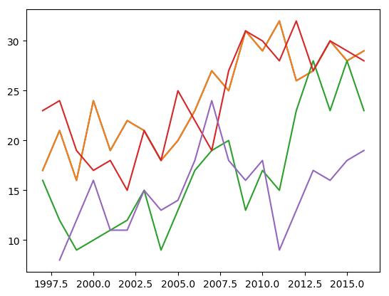

```python
plt.figure()
plt.plot(rma_w)
plt.plot(atm_w)
plt.plot(fcb_w)
plt.plot(vil_w)
plt.show()
```

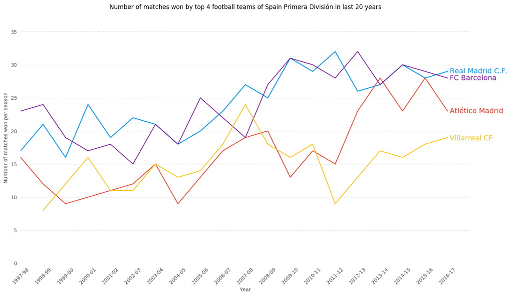

```python
plt.figure()
plt.figure(figsize=(16, 9))
plt.title('Number of matches won by top 4 football teams of Spain Primera División in last 20 years')
plt.plot(rma_w,c='xkcd:azure')
plt.plot(atm_w,c='xkcd:tomato')
plt.plot(fcb_w,c='xkcd:purple')
plt.plot(vil_w,c='xkcd:goldenrod')
plt.xlabel(s='Year',alpha=0.7)
plt.ylabel(s='Number of matches won per season',alpha=0.7)
plt.xticks(season_x,season_labels, rotation='45')
plt.xticks(alpha=0.7)
plt.yticks(alpha=0.7)

ax=plt.gca()
ax.yaxis.grid(color='gray', linestyle='dashed',alpha=0.3)
ax.spines["top"].set_visible(False)
ax.spines["bottom"].set_visible(False)
ax.spines["right"].set_visible(False)
ax.spines["left"].set_visible(False)

plt.ylim(0, 38)
plt.xlim(1997, 2017)

plt.tick_params(axis="both", which="both", bottom="off", top="off",
                labelbottom="on", left="off", right="off", labelleft="on")
plt.text(x =2016.1, y = 28.7,s='Real Madrid C.F.', fontsize=14,color='xkcd:azure')
plt.text(x =2016.1, y = 27.7,s='FC Barcelona', fontsize=14,color='xkcd:purple')
plt.text(x =2016.1, y = 22.7,s='Atlético Madrid', fontsize=14,color='xkcd:tomato')
plt.text(x =2016.1, y = 18.6,s='Villarreal CF', fontsize=14,color='xkcd:goldenrod')
plt.show()
```